# Исследовательский анализ данных Яндекс Недвижимость

#### Площадь кухни:

```
0.5271573429123066
```

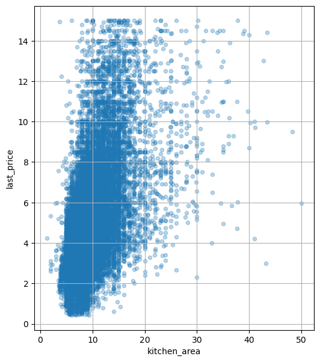

```python
data.plot(x='kitchen_area', y='last_price', kind='scatter',figsize=(6, 7), sharex=False, grid=True, alpha=0.3)
data['kitchen_area'].corr(data['last_price'])
```

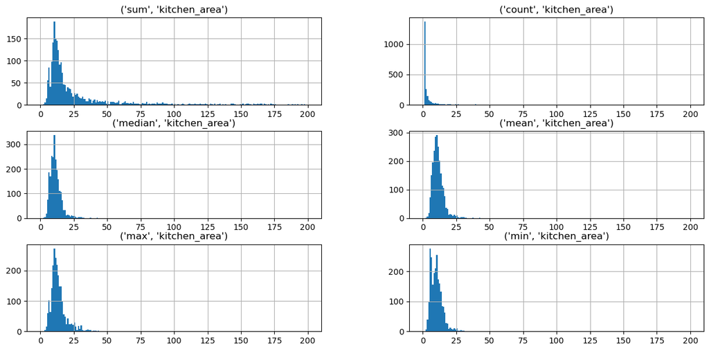

```python
pivot_table_kitchen_area = data.pivot_table(index = 'last_price', values = 'kitchen_area', aggfunc = ['sum', 'count', 'median', 'mean', 'max', 'min'])
pivot_table_kitchen_area.hist(bins=200, grid=True, figsize = (15,7), range = (0,200));
```

Зависимость между площадью кухни и стоимостью объекта есть. Коэффициент корреляции Пирсона равен 0.53, т.е положительная корреляция. С увеличением площади кухни обьекта увеличивается цена обьекта. Максимально высокое влияние на стоимость обьекта является площадь кухни 10 м2. Минимальное влияние на стоимость обьекта является площадь кухни 8 м2.

#### Количество комнат:

```
0.42879126647636917
```

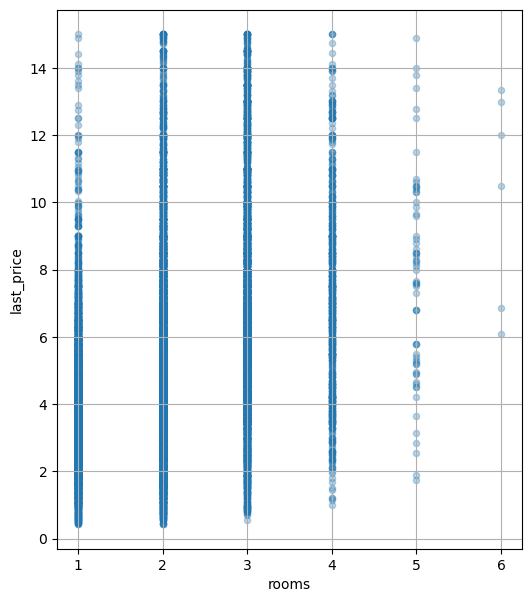

```python
data.plot(x='rooms', y='last_price', kind='scatter',figsize=(6, 7), sharex=False, grid=True, alpha=0.3)
data['rooms'].corr(data['last_price'])
```

| rooms | mean | count | median |
| --- | --- | --- | --- |
| 6 | 10.300833 | 6 | 11.250 |
| 5 | 7.713750 | 64 | 7.825 |
| 4 | 7.052257 | 718 | 6.900 |
| 3 | 6.422077 | 5205 | 5.880 |
| 2 | 5.184463 | 7731 | 4.700 |
| 1 | 3.785095 | 7967 | 3.600 |

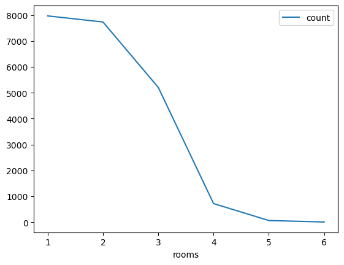

```python
pivot_table_floor_rooms = data.pivot_table(index = ['rooms'], values = 'last_price', aggfunc = ['mean', 'count', 'median'])
pivot_table_floor_rooms.columns = ['mean', 'count', 'median']
pivot_table_floor_rooms.plot(y = 'count')
pivot_table_floor_rooms.sort_values('median', ascending = False)
```

Зависимость между количеством комнат и стоимостью объекта небольшая - согласно корреляции Пирсона - 0.43. Максимальное влияние на стоимость обьекта является количество комнат 1,2. Минимальное влияние на стоимость обьекта является количество комнат больше 4.

#### Этажи, на котором расположена квартира (первый, последний, другой):

```
0.12934440883140713
```

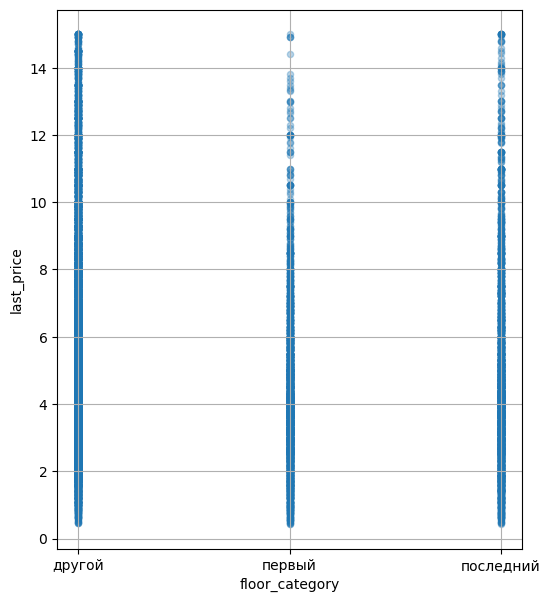

```python
data.plot(x='floor_category', y='last_price', kind='scatter',figsize=(6, 7), sharex=False, grid=True, alpha=0.3)
data['floor'].corr(data['last_price'])
```

| floor_category | mean | count | median |
| --- | --- | --- | --- |
| другой | 5.258850 | 15911 | 4.65 |
| последний | 4.641161 | 3004 | 4.10 |
| первый | 4.202893 | 2776 | 3.85 |

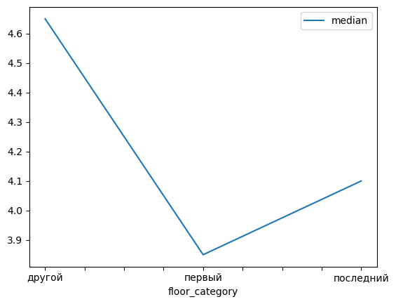

```python
pivot_table_floor_category = data.pivot_table(index = ['floor_category'], values = 'last_price', aggfunc = ['mean', 'count', 'median'])
pivot_table_floor_category.columns = ['mean', 'count', 'median']
pivot_table_floor_category.plot(y = 'median')
pivot_table_floor_category.sort_values('median', ascending = False)
```

Зависимость между этажами и стоимостью объекта очень слабая - согласно корреляции Пирсона - 0.13. На стоимость обьекта максимальное влияние оказывает другой этаж. Минимальное влияние на стоимость обьекта оказывает первый, т.е самые дешевые квартиры на первом этаже. На втором месте - это последнии этажи, т.е. обьекты незначительно дороже первого этажа.

#### Даты размещения (день недели, месяц, год):

| year | mean | count | median |
| --- | --- | --- | --- |
| 2014 | 6.589868 | 97 | 5.90 |
| 2015 | 5.466000 | 1018 | 4.95 |
| 2019 | 5.359981 | 2658 | 4.90 |
| 2018 | 4.963975 | 7931 | 4.45 |
| 2017 | 4.950572 | 7468 | 4.33 |
| 2016 | 4.959212 | 2519 | 4.30 |

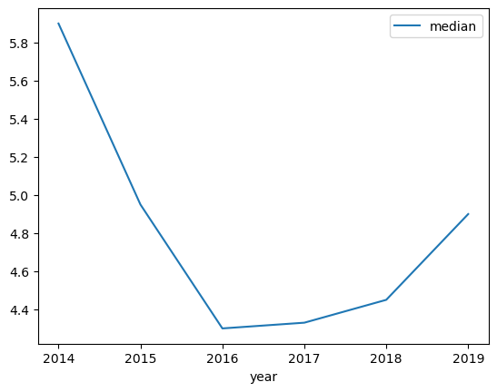

```python
pivot_table_year = data.pivot_table(index = ['year'], values = 'last_price', aggfunc = ['mean', 'count', 'median'])
pivot_table_year.columns = ['mean', 'count', 'median']
pivot_table_year.plot(y = 'median')
pivot_table_year.sort_values('median', ascending = False)
```

Выборге данных анализируем средную цену с 2014 до 2016 года цена падала, c 2018 цена начала увеличиваться! Это свзяно с общей инфляцией в стране.

| month_publication | mean | count | median |
| --- | --- | --- | --- |
| апрель | 5.157529 | 2189 | 4.60 |
| декабрь | 5.033376 | 1496 | 4.50 |
| март | 5.030929 | 2387 | 4.50 |
| ноябрь | 5.086169 | 2152 | 4.50 |
| сентябрь | 5.157556 | 1796 | 4.50 |
| январь | 5.012628 | 1366 | 4.50 |
| август | 5.066875 | 1598 | 4.49 |
| февраль | 5.008933 | 2427 | 4.49 |
| июль | 5.025581 | 1538 | 4.45 |
| октябрь | 5.005173 | 1958 | 4.45 |
| май | 4.980966 | 1162 | 4.40 |
| июнь | 4.825959 | 1622 | 4.25 |

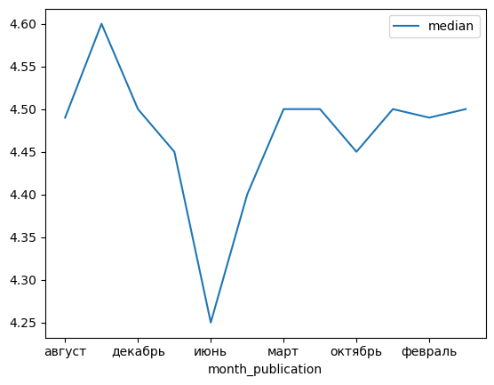

```python
pivot_table_month_publication = data.pivot_table(index = ['month_publication'], values = 'last_price', aggfunc = ['mean', 'count', 'median'])
pivot_table_month_publication.columns = ['mean', 'count', 'median']
pivot_table_month_publication.plot(y = 'median')
pivot_table_month_publication.sort_values('median', ascending = False)
```

Самые минимальные цены в июне это свзано с тем, что люди в этом месяце думают об летнем отдыхе и только с августа по сентябрь начинают думать о смене жилья.

| day_publication | mean | count | median |
| --- | --- | --- | --- |
| вторник | 5.109831 | 3841 | 4.550 |
| понедельник | 5.034825 | 3313 | 4.500 |
| среда | 5.051522 | 3607 | 4.500 |
| четверг | 5.055835 | 3894 | 4.485 |
| воскресенье | 4.991844 | 1575 | 4.450 |
| пятница | 5.009309 | 3672 | 4.450 |
| суббота | 4.925106 | 1789 | 4.450 |

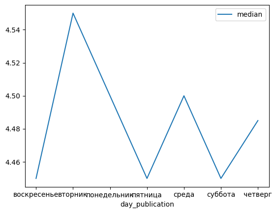

```python
pivot_table_day_publication = data.pivot_table(index = ['day_publication'], values = 'last_price', aggfunc = ['mean', 'count', 'median'])
pivot_table_day_publication.columns = ['mean', 'count', 'median']
pivot_table_day_publication.plot(y = 'median')
pivot_table_day_publication.sort_values('median', ascending = False)
```

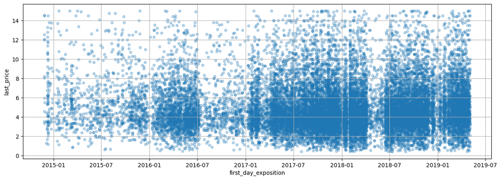

```python
data.plot(x='first_day_exposition', y='last_price', kind='scatter',figsize=(15, 5), sharex=False, grid=True, alpha=0.3);
```

| first_day_exposition | mean | count | median |
| --- | --- | --- | --- |
| 2016-09-12 | 13.800 | 1 | 13.800 |
| 2015-08-23 | 10.860 | 5 | 12.650 |
| 2016-01-04 | 12.300 | 1 | 12.300 |
| 2015-09-04 | 12.000 | 1 | 12.000 |
| 2016-12-10 | 11.500 | 1 | 11.500 |
| ... | ... | ... | ... |
| 2015-09-19 | 1.550 | 1 | 1.550 |
| 2015-01-15 | 1.500 | 1 | 1.500 |
| 2016-12-26 | 1.375 | 2 | 1.375 |
| 2014-12-05 | 1.300 | 1 | 1.300 |
| 2015-04-04 | 1.260 | 1 | 1.260 |

1479 rows × 3 columns

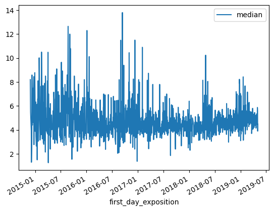

```python
pivot_table_first_day_exposition = data.pivot_table(index = ['first_day_exposition'], values = 'last_price', aggfunc = ['mean', 'count', 'median'])
pivot_table_first_day_exposition.columns = ['mean', 'count', 'median']
pivot_table_first_day_exposition.plot(y = 'median')
pivot_table_first_day_exposition.sort_values('median', ascending = False)
```

**Вывод: Шаг 4.3.** Изучили факторы, влияющие на общую (полную) стоимость объекта:

- на первом месте зависимости цены от общей площади объекта, r = 0.72;
- на втором месте зависимости цены от жилой площади объекта, r = 0.59;
- на третьем месте зависимости цены от площади кухни объекта, r = 0.53.

С увеличением площади обьекта увеличивается цена обьекта. Максимально высокое влияние на стоимость обьекта является площадь 60 м2. Минимальное влияние на стоимость обьекта является площадь 30 м2.

С увеличением жилой площади обьекта увеличивается цена обьекта. Максимально высокое влияние на стоимость обьекта является жилая площадь 15, 30 м2. Минимальное влияние на стоимость обьекта является жилая площадь 18 м2.

С увеличением площади кухни обьекта увеличивается цена обьекта. Максимально высокое влияние на стоимость обьекта является площадь кухни 10 м2. Минимальное влияние на стоимость обьекта является площадь кухни 8 м2.

Небольшое влияние на цену оказывают: количеством комнат объекта, этажи, на котором расположена квартира.

### Посчитаем среднюю цену одного квадратного метра в 10 населённых пунктах с наибольшим числом объявлений. Выделим населённые пункты с самой высокой и низкой стоимостью квадратного метра. Эти данные можно найти по имени в столбце locality_name.

```python
locality_pivot_table = data.pivot_table(index = 'locality_name', values = 'price_meter', aggfunc=['count', 'mean'])
locality_pivot_table.columns = ['count', 'mean']
locality_pivot_table = locality_pivot_table.sort_values('count', ascending = False).head(10)
locality_pivot_table
```

| locality_name | count | mean |
| --- | --- | --- |
| Санкт-Петербург | 13942 | 107553.728378 |
| поселок Мурино | 525 | 85024.818605 |
| Кудрово | 448 | 95046.476194 |
| поселок Шушары | 430 | 78310.015469 |
| Всеволожск | 387 | 67188.420478 |
| Пушкин | 341 | 101190.553506 |
| Колпино | 336 | 75370.025473 |
| поселок Парголово | 322 | 90448.423806 |
| Гатчина | 304 | 68919.469270 |
| Выборг | 227 | 58192.689864 |

```python
#самая низкая стоимость
locality_pivot_table[locality_pivot_table['mean']==locality_pivot_table['mean'].min()]
```

| locality_name | count | mean |
| --- | --- | --- |
| Выборг | 227 | 58192.689864 |

```python
#самая высокая стоимость
locality_pivot_table[locality_pivot_table['mean']==locality_pivot_table['mean'].max()]
```

| locality_name | count | mean |
| --- | --- | --- |
| Санкт-Петербург | 13942 | 107553.728378 |

Самая высокая стоимость жилья из 10 населённых пунктов с самым большим количеством объявлений в Санкт-Петербурге, тогда как самая низкая стоимость в Выборге.

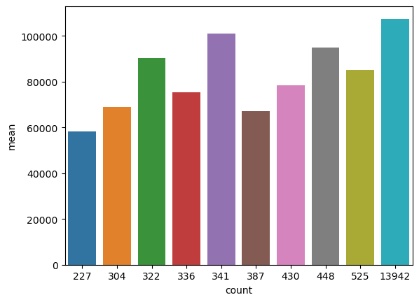

```python
sns.barplot(data=locality_pivot_table, x='count', y='mean');
```

#### Выделим квартиры в Санкт-Петербурге с помощью столбца locality_name и вычислим среднюю цену каждого километра. Опишем, как стоимость объектов зависит от расстояния до центра города.

| cityCenters_nearest | price_meter |
| --- | --- |
| 0 | 127536.626329 |
| 1 | 127796.860619 |
| 2 | 119895.494790 |
| 3 | 116707.320980 |
| 4 | 125337.675332 |
| 5 | 124575.660929 |
| 6 | 123485.741255 |
| 7 | 120942.660914 |
| 8 | 114756.891385 |
| 9 | 107666.094079 |
| 10 | 108133.469849 |
| 11 | 105351.157631 |
| 12 | 107339.274675 |
| 13 | 106460.222213 |
| 14 | 103811.389700 |
| 15 | 101648.208182 |
| 16 | 98965.843485 |
| 17 | 94405.674380 |
| 18 | 94872.591508 |
| 19 | 95994.724627 |
| 20 | 106395.588100 |
| 21 | 91778.336872 |
| 22 | 88597.423798 |
| 23 | 92293.834762 |
| 24 | 82440.343912 |
| 25 | 90436.945589 |
| 26 | 75171.911041 |
| 27 | 132115.709459 |
| 28 | 83326.435417 |
| 29 | 62482.404228 |

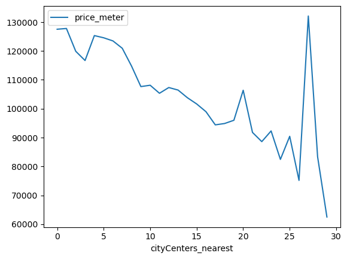

```python
pivot_table_km = data.query('locality_name == "Санкт-Петербург"').pivot_table(index = 'cityCenters_nearest', values = 'price_meter', aggfunc = 'mean')
pivot_table_km.plot()
pivot_table_km
```

```python
data['floor'].corr(data['last_price'])
```

```
0.12934440883140713
```

**Вывод: Шаг 4.4** Стоимость объектов зависит от расстояния до центра города. Чем ближе к центру, тем выше цена. Локальные всплески цен на графике говорят нам о том, что независимо от удаленности от центра, в элитных районах Санкт-Петербурга с развитой инфрастуктурой цены выше. На мой взгляд центр Санкт-Петербурга заканчивается на 7-8 км. После того как заканчивается центр всплески цен обусловлены элитными застройками.

# Шаг 5. Общие вывод

**Вывод:**